# Predictive Models Take Home Exam

Hitesh Prabhu

July 27, 2016

## Question 1 - Chapter 2 | Problem 10

### 1.a

```r
library(MASS)
# head(Boston)
# ?Boston
str(Boston)
```

```
## 'data.frame':    506 obs. of  14 variables:
##  $ crim   : num  0.00632 0.02731 0.02729 0.03237 0.06905 ...
##  $ zn     : num  18 0 0 0 0 0 12.5 12.5 12.5 12.5 ...
##  $ indus  : num  2.31 7.07 7.07 2.18 2.18 2.18 7.87 7.87 7.87 7.87 ...
##  $ chas   : int  0 0 0 0 0 0 0 0 0 0 ...
##  $ nox    : num  0.538 0.469 0.469 0.458 0.458 0.458 0.524 0.524 0.524 0.524 ...
##  $ rm     : num  6.58 6.42 7.18 7 7.15 ...
##  $ age    : num  65.2 78.9 61.1 45.8 54.2 58.7 66.6 96.1 100 85.9 ...
##  $ dis    : num  4.09 4.97 4.97 6.06 6.06 ...
##  $ rad    : int  1 2 2 3 3 3 5 5 5 5 ...
##  $ tax    : num  296 242 242 222 222 222 311 311 311 311 ...
##  $ ptratio: num  15.3 17.8 17.8 18.7 18.7 18.7 15.2 15.2 15.2 15.2 ...
##  $ black  : num  397 397 393 395 397 ...
##  $ lstat  : num  4.98 9.14 4.03 2.94 5.33 ...
##  $ medv   : num  24 21.6 34.7 33.4 36.2 28.7 22.9 27.1 16.5 18.9 ...
```

```r
n <- dim(Boston)
cat("Number of rows = ", n[1], "\nNumber of columns", n[2], "\n")
```

```
## Number of rows =  506
## Number of columns 14
```

There are 506 obs and 14 columns in the Boston dataset

This dataset contains information collected by the U.S CensusService concerning housing in the area of Boston, Massachusetts. The rows represent different suburbs in Boston whereas the columns represent various characteristics of that area:

| Variable Name | Description |
| --- | --- |
| crim | per capita crime rate by town. |
| zn | proportion of residential land zoned for lots over 25,000 sq.ft. |
| indus | proportion of non-retail business acres per town. |
| chas | Charles River dummy variable (= 1 if tract bounds river; 0 otherwise). |
| nox | nitrogen oxides concentration (parts per 10 million). |
| rm | average number of rooms per dwelling. |
| age | proportion of owner-occupied units built prior to 1940. |
| dis | weighted mean of distances to five Boston employment centres. |
| rad | index of accessibility to radial highways. |
| tax | full-value property-tax rate per $10,000. |
| ptratio | pupil-teacher ratio by town. |
| black | 1000(Bk - 0.63)^2 where Bk is the proportion of blacks by town. |
| lstat | lower status of the population (percent). |
| medv | median value of owner-occupied homes in $1000s. |

### 1.b

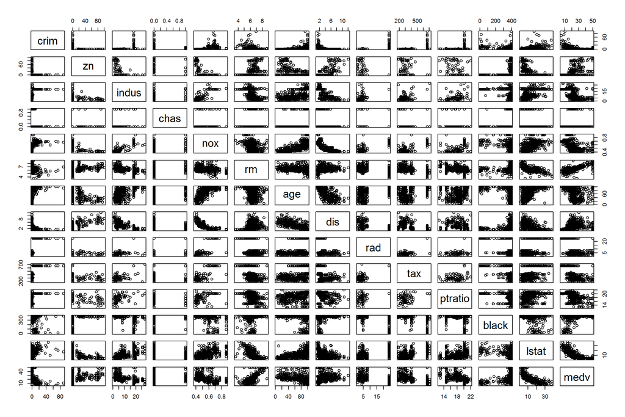

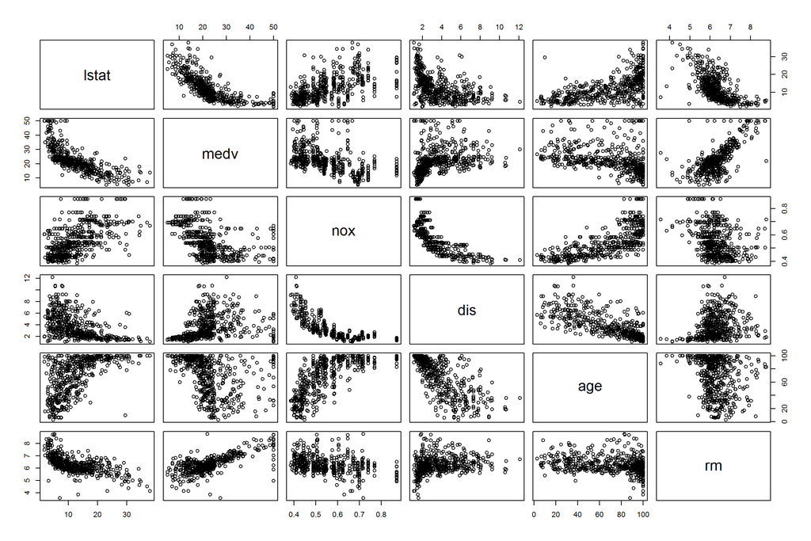

- lstat and medv have a negative relationship
- Houses with high medv have low crime rates (crim)
- Nitrogen oxide concentration (nox) reduces as distance from employment centres (dis) increases, but non-linearly.
- There is a linear relationship (few outliers) between medv and rm (no of rooms)

### 1.c

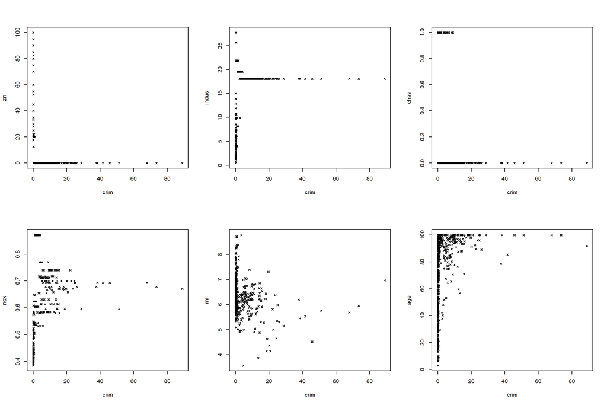

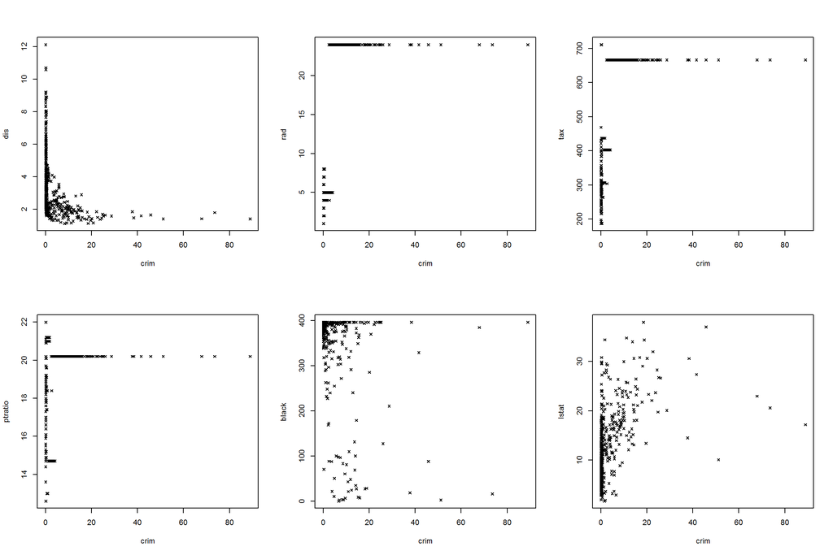

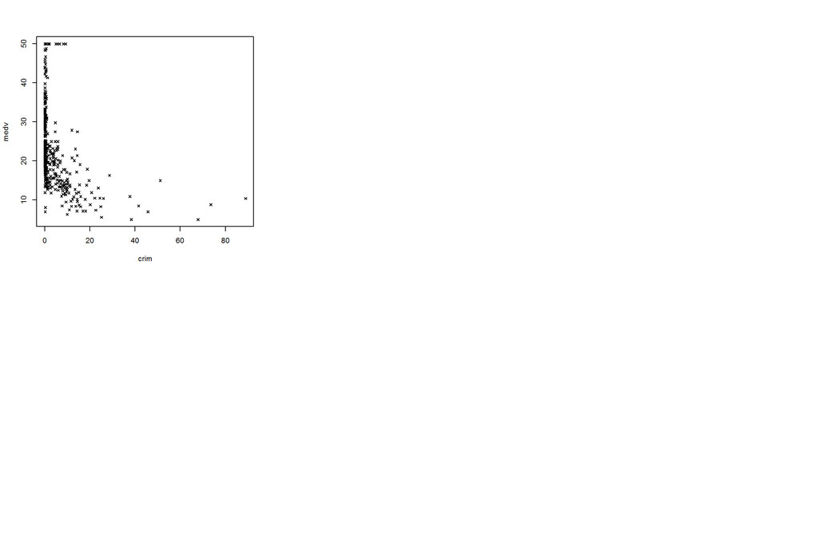

```r
par(mfrow = c(2, 3))

sapply(2:length(Boston), function(x)
  {
    plot(Boston[,c(1,x)], pch = 4, cex=0.7)
  }
)
```

Yes, there are predictors that are associated with crime rate. * chas -> Most of the crimes occur away from the river. however this may be misleading as most of the recorded observations are away from the river * age -> areas with high number of old houses tend to have higher crime rates * dis -> crime rates are higher in areas which are closer to Boston’s employment centres * medv -> areas with more higher priced homes have lower crime rates. Some high price areas have high crime rates

### 1.d

```r
sortedBy_crime_rates <- Boston[order(Boston$crim, decreasing = T),]
sortedBy_crime_rates[1:6,]
```

```
##        crim zn indus chas   nox    rm   age    dis rad tax ptratio  black
## 381 88.9762  0  18.1    0 0.671 6.968  91.9 1.4165  24 666    20.2 396.90
## 419 73.5341  0  18.1    0 0.679 5.957 100.0 1.8026  24 666    20.2  16.45
## 406 67.9208  0  18.1    0 0.693 5.683 100.0 1.4254  24 666    20.2 384.97
## 411 51.1358  0  18.1    0 0.597 5.757 100.0 1.4130  24 666    20.2   2.60
## 415 45.7461  0  18.1    0 0.693 4.519 100.0 1.6582  24 666    20.2  88.27
## 405 41.5292  0  18.1    0 0.693 5.531  85.4 1.6074  24 666    20.2 329.46
##     lstat medv
## 381 17.21 10.4
## 419 20.62  8.8
## 406 22.98  5.0
## 411 10.11 15.0
## 415 36.98  7.0
## 405 27.38  8.5
```

```r
sortedBy_tax <- Boston[order(Boston$tax, decreasing = T),]
sortedBy_tax[1:6,]
```

```
##        crim zn indus chas   nox    rm  age    dis rad tax ptratio  black
## 489 0.15086  0 27.74    0 0.609 5.454 92.7 1.8209   4 711    20.1 395.09
## 490 0.18337  0 27.74    0 0.609 5.414 98.3 1.7554   4 711    20.1 344.05
## 491 0.20746  0 27.74    0 0.609 5.093 98.0 1.8226   4 711    20.1 318.43
## 492 0.10574  0 27.74    0 0.609 5.983 98.8 1.8681   4 711    20.1 390.11
## 493 0.11132  0 27.74    0 0.609 5.983 83.5 2.1099   4 711    20.1 396.90
## 357 8.98296  0 18.10    1 0.770 6.212 97.4 2.1222  24 666    20.2 377.73
##     lstat medv
## 489 18.06 15.2
## 490 23.97  7.0
## 491 29.68  8.1
## 492 18.07 13.6
## 493 13.35 20.1
## 357 17.60 17.8
```

```r
sortedBy_ptratio <- Boston[order(Boston$ptratio, decreasing = T),]
sortedBy_ptratio[1:6,]
```

```
##        crim zn indus chas   nox    rm  age     dis rad tax ptratio  black
## 355 0.04301 80  1.91    0 0.413 5.663 21.9 10.5857   4 334    22.0 382.80
## 356 0.10659 80  1.91    0 0.413 5.936 19.5 10.5857   4 334    22.0 376.04
## 128 0.25915  0 21.89    0 0.624 5.693 96.0  1.7883   4 437    21.2 392.11
## 129 0.32543  0 21.89    0 0.624 6.431 98.8  1.8125   4 437    21.2 396.90
## 130 0.88125  0 21.89    0 0.624 5.637 94.7  1.9799   4 437    21.2 396.90
## 131 0.34006  0 21.89    0 0.624 6.458 98.9  2.1185   4 437    21.2 395.04
##     lstat medv
## 355  8.05 18.2
## 356  5.57 20.6
## 128 17.19 16.2
## 129 15.39 18.0
## 130 18.34 14.3
## 131 12.60 19.2
```

```r
summary(Boston)
```

```
##       crim                zn             indus            chas
##  Min.   : 0.00632   Min.   :  0.00   Min.   : 0.46   Min.   :0.00000
##  1st Qu.: 0.08204   1st Qu.:  0.00   1st Qu.: 5.19   1st Qu.:0.00000
##  Median : 0.25651   Median :  0.00   Median : 9.69   Median :0.00000
##  Mean   : 3.61352   Mean   : 11.36   Mean   :11.14   Mean   :0.06917
##  3rd Qu.: 3.67708   3rd Qu.: 12.50   3rd Qu.:18.10   3rd Qu.:0.00000
##  Max.   :88.97620   Max.   :100.00   Max.   :27.74   Max.   :1.00000
##       nox               rm             age              dis
##  Min.   :0.3850   Min.   :3.561   Min.   :  2.90   Min.   : 1.130
##  1st Qu.:0.4490   1st Qu.:5.886   1st Qu.: 45.02   1st Qu.: 2.100
##  Median :0.5380   Median :6.208   Median : 77.50   Median : 3.207
##  Mean   :0.5547   Mean   :6.285   Mean   : 68.57   Mean   : 3.795
##  3rd Qu.:0.6240   3rd Qu.:6.623   3rd Qu.: 94.08   3rd Qu.: 5.188
##  Max.   :0.8710   Max.   :8.780   Max.   :100.00   Max.   :12.127
##       rad              tax           ptratio          black
##  Min.   : 1.000   Min.   :187.0   Min.   :12.60   Min.   :  0.32
##  1st Qu.: 4.000   1st Qu.:279.0   1st Qu.:17.40   1st Qu.:375.38
##  Median : 5.000   Median :330.0   Median :19.05   Median :391.44
##  Mean   : 9.549   Mean   :408.2   Mean   :18.46   Mean   :356.67
##  3rd Qu.:24.000   3rd Qu.:666.0   3rd Qu.:20.20   3rd Qu.:396.23
##  Max.   :24.000   Max.   :711.0   Max.   :22.00   Max.   :396.90
##      lstat            medv
##  Min.   : 1.73   Min.   : 5.00
##  1st Qu.: 6.95   1st Qu.:17.02
##  Median :11.36   Median :21.20
##  Mean   :12.65   Mean   :22.53
##  3rd Qu.:16.95   3rd Qu.:25.00
##  Max.   :37.97   Max.   :50.00
```

### 1.e

```r
table(Boston$chas)
```

```
##
##   0   1
## 471  35
```

35 suburbs bound the Charles river

### 1.f

```r
summary(Boston$ptratio)
```

```
##    Min. 1st Qu.  Median    Mean 3rd Qu.    Max.
##   12.60   17.40   19.05   18.46   20.20   22.00
```

Median value is 19.05

### 1.g

```r
which.min(Boston$medv)
```

```
## [1] 399
```

```r
Boston[which.min(Boston$medv),]
```

```
##        crim zn indus chas   nox    rm age    dis rad tax ptratio black
## 399 38.3518  0  18.1    0 0.693 5.453 100 1.4896  24 666    20.2 396.9
##     lstat medv
## 399 30.59    5
```

the 399th suburb of Boston the lowest value of house prices

crim zn indus chas nox rm age dis rad tax 38.3518 0 18.1 0 0.693 5.453 100 1.4896 24 666 ptratio black lstat medv 20.2 396.9 30.59 5

Crime rates - Crime rates are high and lie between the 3rd and 4th quartile zn - there is no land zoned for large lots which is in the lowest point in the range with the lowest value indus - indus value lies at the end of the 3rd quartile of the range chas - It does not lie along the Charles river like most other suburbs nox - it lies between the 3rd and 4th quartile of teh range rm - it lies in the first quartile in the range age - it is at the highest point of the range with the max value dis - it lies in the first quartile of the range rad - it is at the highest point of the range with the max value tax (full-value property-tax rate per /$10,000.) - is on the higher side, and lies at the third quaritle (666) ptratio (pupil-teacher ratio) - is amongst the highest and lies at the third quartile of the dataset (20.20) black (1000(Bk - 0.63)^2 where Bk is the proportion of blacks by town.) - is the maximum value in the dataset (396.9) lstat - (lower status of the population in percent) is very high. Lies between 3rd quartile (16.95) and max (37.97)

### 1.h

```r
dim(Boston[which(Boston$rm > 7), ])[1]
```

```
## [1] 64
```

```r
dim(Boston[which(Boston$rm > 8), ])[1]
```

```
## [1] 13
```

## Question 2 - Problem 15 | Chapter 3

### 2.a

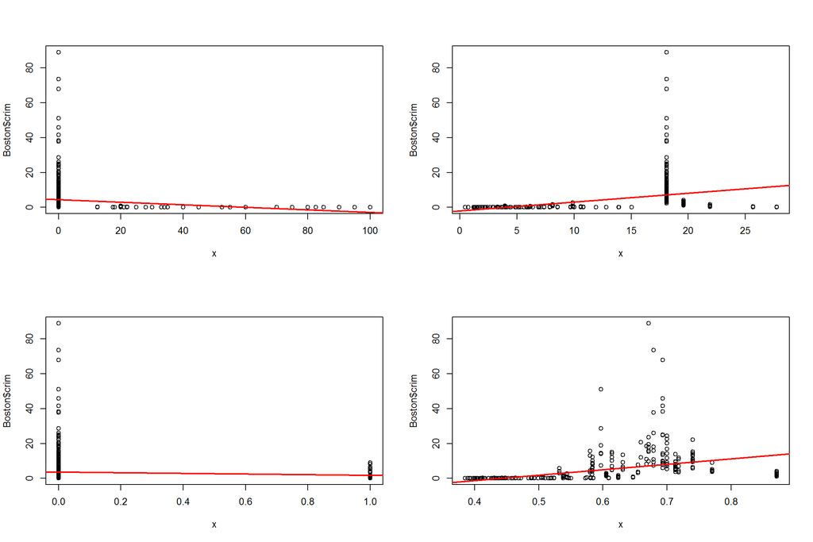

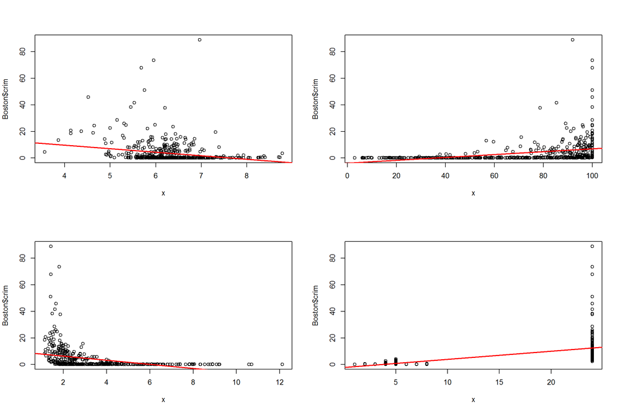

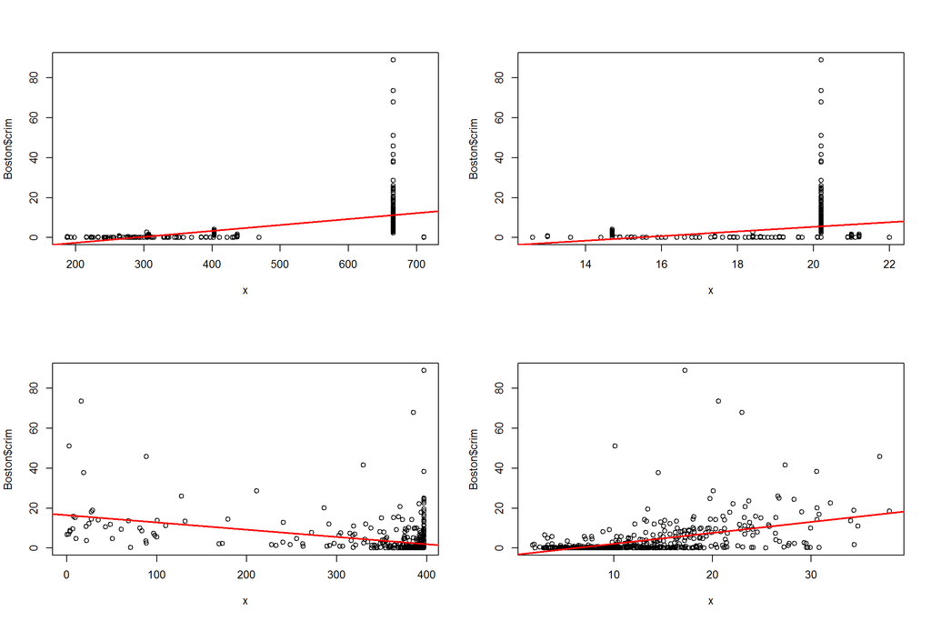

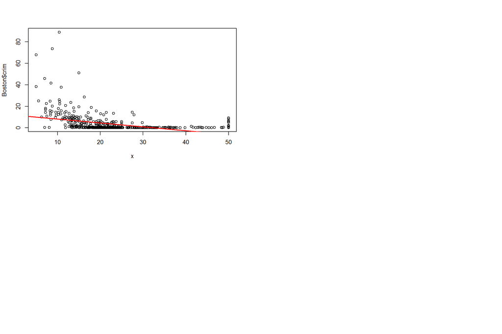

```r
library (MASS)
Boston$index = NULL

lapply( Boston[,-1], function(x) {
  summary(lm(Boston$crim ~ x))
  }
)

par(mfrow = c(2, 2))
lapply( Boston[,-1], function(x) {
    model <- lm(Boston$crim ~ x)
    plot(x, Boston$crim)
    abline(model$coef[1],model$coef[2],col=2,lwd=2)
  }
)
```

[output not shown]

There is some statistical significance observed in models using the following variables: zn, indus, nox, rm, age, dis, rad, tax, ptratio, black, lstat, medv

### 2.b

```r
multilinear_model <- lm(crim ~ .,data=Boston)
summary(multilinear_model)
```

```
##
## Call:
## lm(formula = crim ~ ., data = Boston)
##
## Residuals:
##    Min     1Q Median     3Q    Max
## -9.924 -2.120 -0.353  1.019 75.051
##
## Coefficients:
##               Estimate Std. Error t value Pr(>|t|)
## (Intercept)  17.033228   7.234903   2.354 0.018949 *
## zn            0.044855   0.018734   2.394 0.017025 *
## indus        -0.063855   0.083407  -0.766 0.444294
## chas         -0.749134   1.180147  -0.635 0.525867
## nox         -10.313535   5.275536  -1.955 0.051152 .
## rm            0.430131   0.612830   0.702 0.483089
## age           0.001452   0.017925   0.081 0.935488
## dis          -0.987176   0.281817  -3.503 0.000502 ***
## rad           0.588209   0.088049   6.680 6.46e-11 ***
## tax          -0.003780   0.005156  -0.733 0.463793
## ptratio      -0.271081   0.186450  -1.454 0.146611
## black        -0.007538   0.003673  -2.052 0.040702 *
## lstat         0.126211   0.075725   1.667 0.096208 .
## medv         -0.198887   0.060516  -3.287 0.001087 **
## ---
## Signif. codes:  0 '***' 0.001 '**' 0.01 '*' 0.05 '.' 0.1 ' ' 1
##
## Residual standard error: 6.439 on 492 degrees of freedom
## Multiple R-squared:  0.454,  Adjusted R-squared:  0.4396
## F-statistic: 31.47 on 13 and 492 DF,  p-value: < 2.2e-16
```

The variables that we can reject null hypothesis for are: (p<0.05) zn, dis, rad, black, medv

### 2.c

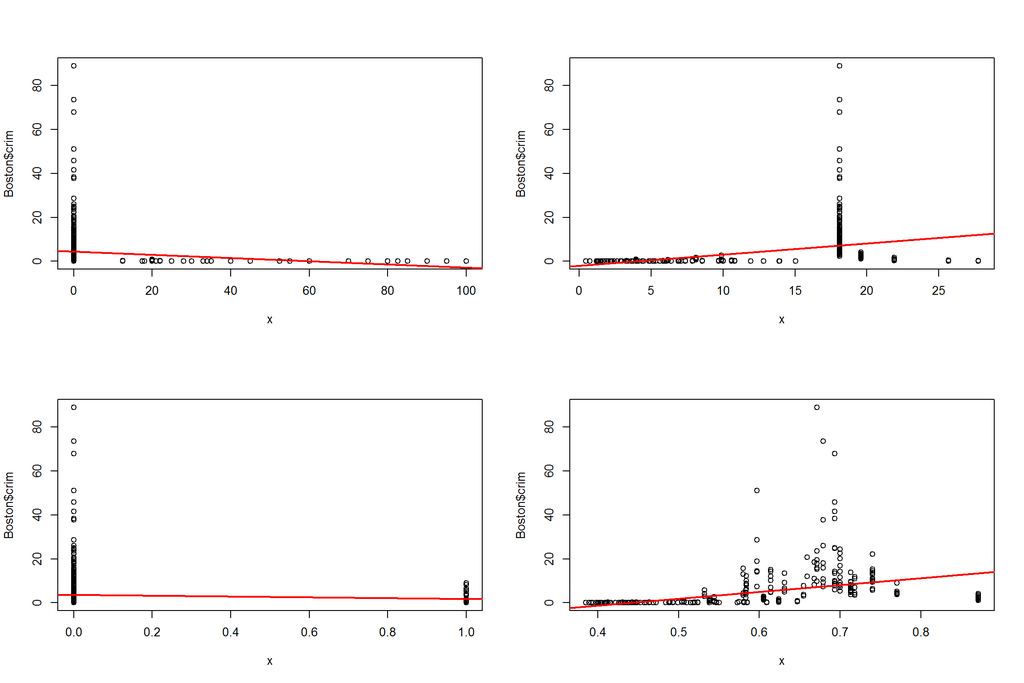

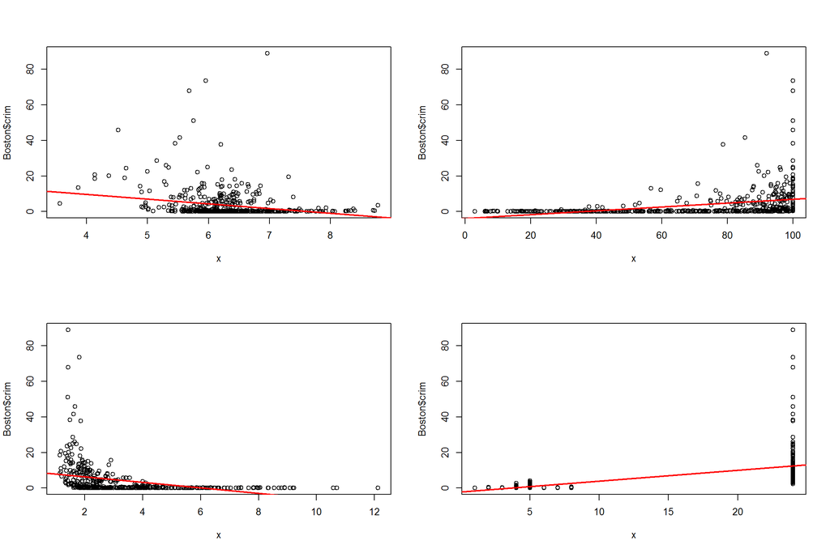

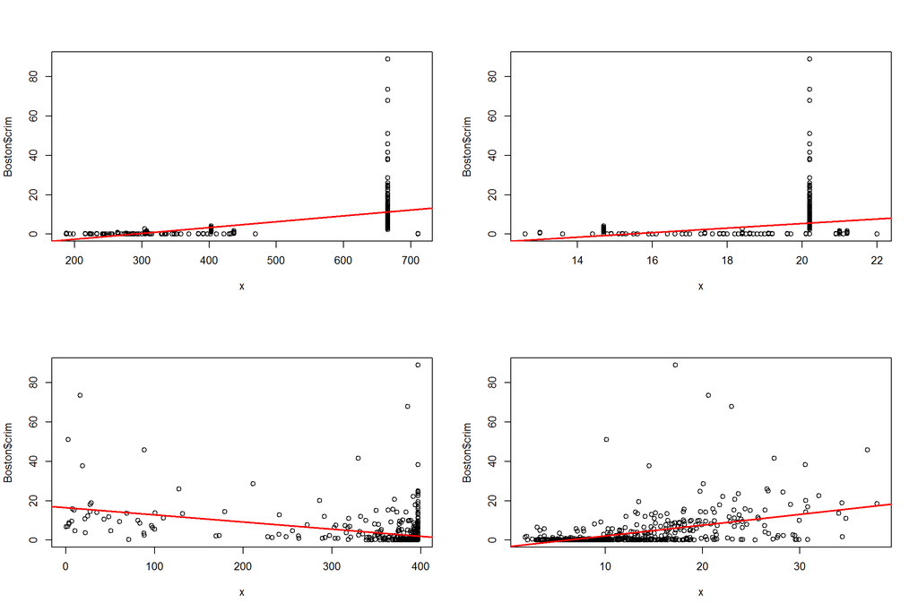

```r
par(mfrow = c(2, 2))
coefficients = NULL
lapply( Boston[,-1], function(x)
  {
    model <- lm(Boston$crim ~ x)
    coefficients <<- c(coefficients,model$coefficients[2])
    plot(x, Boston$crim)
    abline(model$coef[1],model$coef[2],col=2,lwd=2)
  }
      )
```

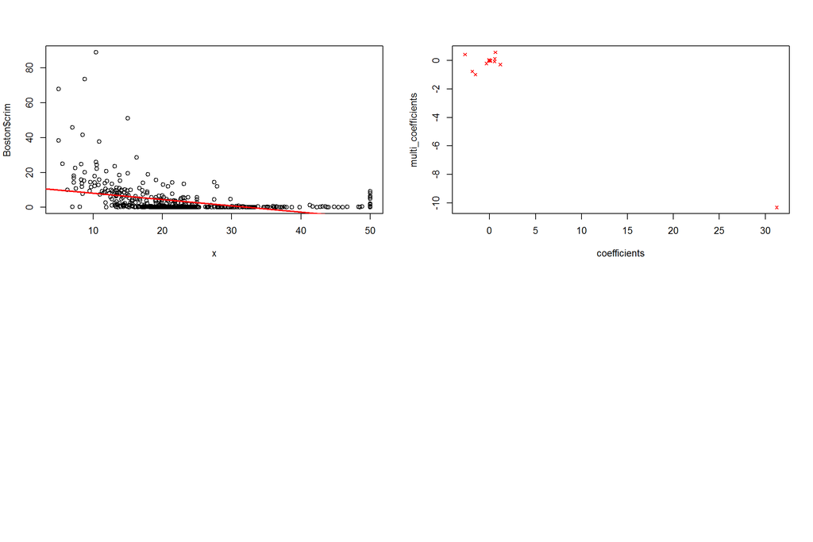

```r
multi_coefficients <- multilinear_model$coefficients[2:14]

names <- NULL
lapply(seq_along(Boston[,-1]), function(x)
  {
    names <<- names(Boston)
  }
      )
names(coefficients) <- names[2:14]

plot(coefficients, multi_coefficients, pch = 4, cex=0.7, col=2)
```

### 2.d

```r
lapply( Boston[,-1], function(x)
  {
    x2 = x^2
    x3 = x^3
    summary(lm(Boston$crim ~ x + x2 + x3))
  }
)
```

```
## $zn
##
## Call:
## lm(formula = Boston$crim ~ x + x2 + x3)
##
## Residuals:
##    Min     1Q Median     3Q    Max
## -4.821 -4.614 -1.294  0.473 84.130
##
## Coefficients:
##               Estimate Std. Error t value Pr(>|t|)
## (Intercept)  4.846e+00  4.330e-01  11.192  < 2e-16 ***
## x           -3.322e-01  1.098e-01  -3.025  0.00261 **
## x2           6.483e-03  3.861e-03   1.679  0.09375 .
## x3          -3.776e-05  3.139e-05  -1.203  0.22954
## ---
## Signif. codes:  0 '***' 0.001 '**' 0.01 '*' 0.05 '.' 0.1 ' ' 1
##
## Residual standard error: 8.372 on 502 degrees of freedom
## Multiple R-squared:  0.05824,    Adjusted R-squared:  0.05261
## F-statistic: 10.35 on 3 and 502 DF,  p-value: 1.281e-06
##
##
## $indus
##
## Call:
## lm(formula = Boston$crim ~ x + x2 + x3)
##
## Residuals:
##    Min     1Q Median     3Q    Max
## -8.278 -2.514  0.054  0.764 79.713
##
## Coefficients:
##               Estimate Std. Error t value Pr(>|t|)
## (Intercept)  3.6625683  1.5739833   2.327   0.0204 *
## x           -1.9652129  0.4819901  -4.077 5.30e-05 ***
## x2           0.2519373  0.0393221   6.407 3.42e-10 ***
## x3          -0.0069760  0.0009567  -7.292 1.20e-12 ***
## ---
## Signif. codes:  0 '***' 0.001 '**' 0.01 '*' 0.05 '.' 0.1 ' ' 1
```

[output cut: 238 more lines]

```
##     Min      1Q  Median      3Q     Max
## -24.427  -1.976  -0.437   0.439  73.655
##
## Coefficients:
##               Estimate Std. Error t value Pr(>|t|)
## (Intercept) 53.1655381  3.3563105  15.840  < 2e-16 ***
## x           -5.0948305  0.4338321 -11.744  < 2e-16 ***
## x2           0.1554965  0.0171904   9.046  < 2e-16 ***
## x3          -0.0014901  0.0002038  -7.312 1.05e-12 ***
## ---
## Signif. codes:  0 '***' 0.001 '**' 0.01 '*' 0.05 '.' 0.1 ' ' 1
##
## Residual standard error: 6.569 on 502 degrees of freedom
## Multiple R-squared:  0.4202, Adjusted R-squared:  0.4167
## F-statistic: 121.3 on 3 and 502 DF,  p-value: < 2.2e-16
```

The following variables have evidence of a nonlinear relationship: indus, nox, dis, ptratio, medv

## Question 3 - Problem 9 | Chapter 6

### 3.a

```r
library(caTools)
library(ISLR)
```

### 3.b

```
## The mean test error obtained was:  1302.75
```

The test error obtained using ordinary least squares regression was 1302.75

### 3.c

```
##     Private        Apps      Accept      Enroll   Top10perc   Top25perc
##           0           0           0           0           0           0
## F.Undergrad P.Undergrad    Outstate  Room.Board       Books    Personal
##           0           0           0           0           0           0
##         PhD    Terminal   S.F.Ratio perc.alumni      Expend   Grad.Rate
##           0           0           0           0           0           0
```

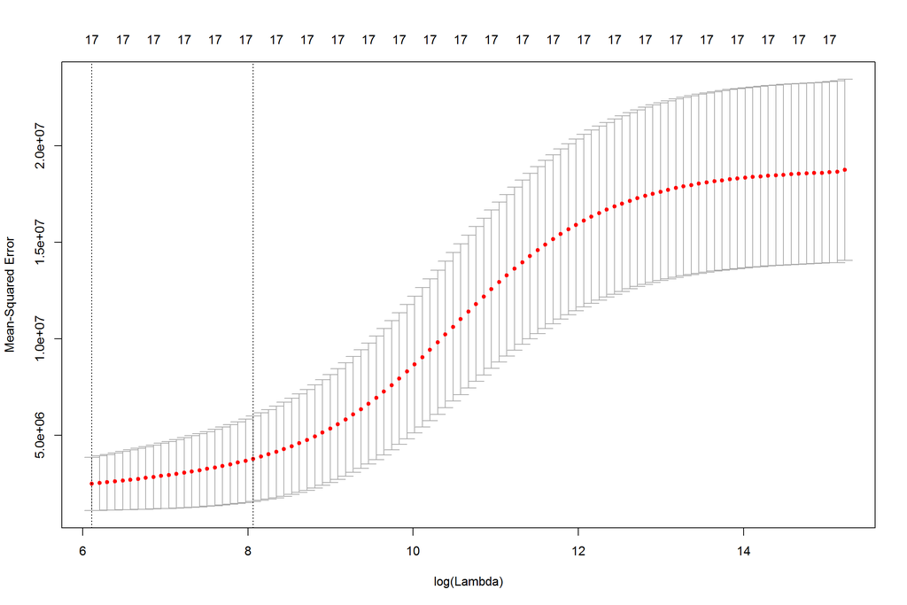

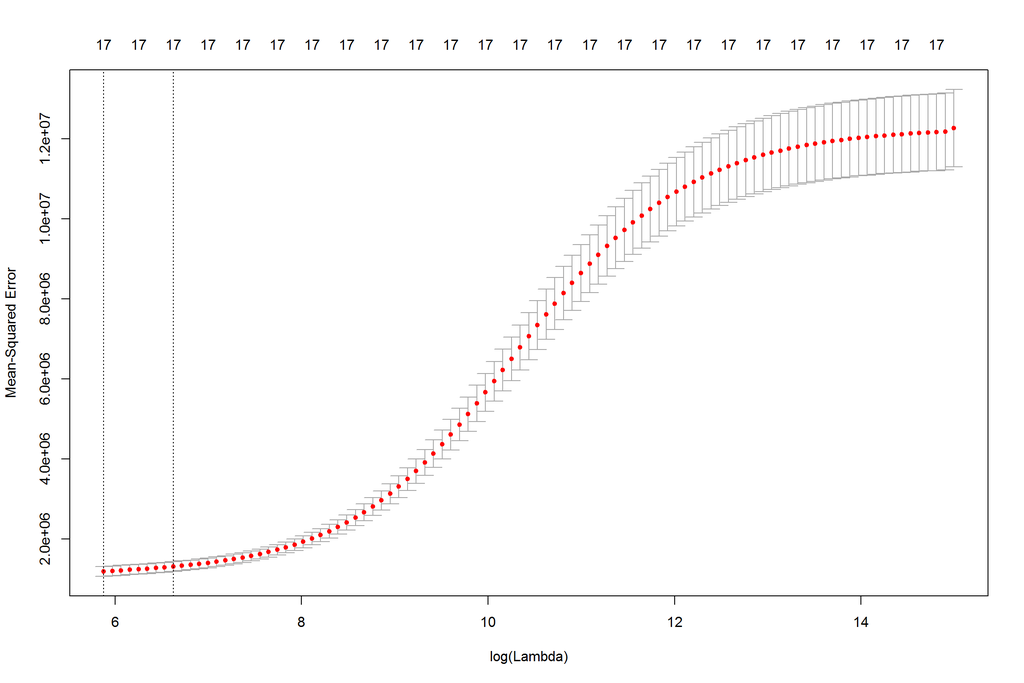

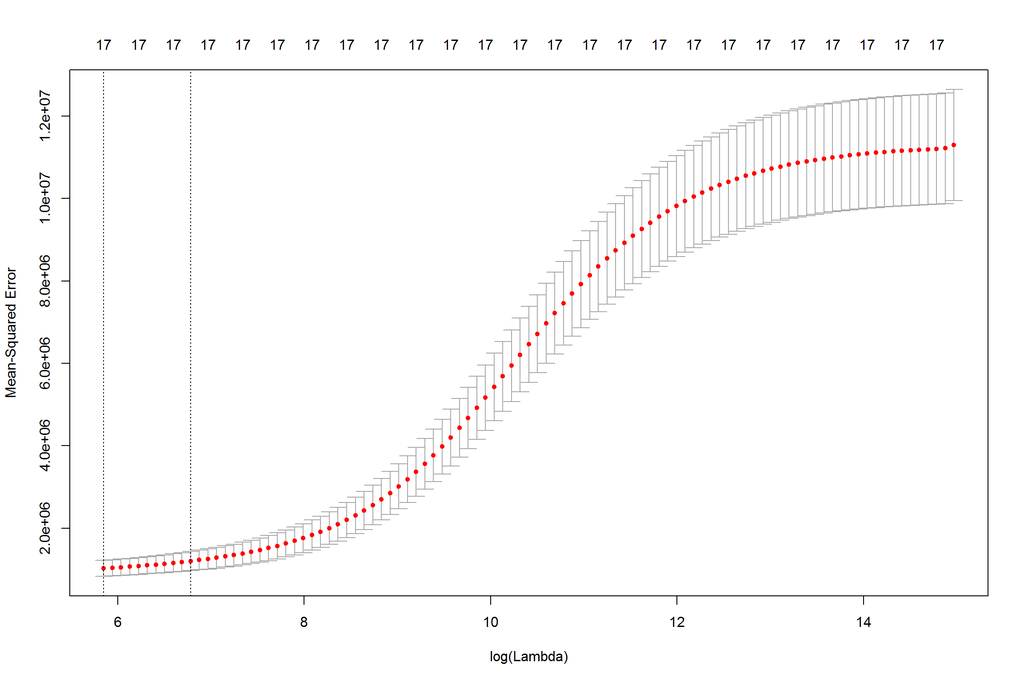

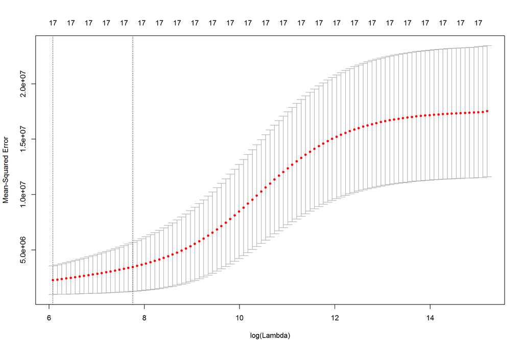

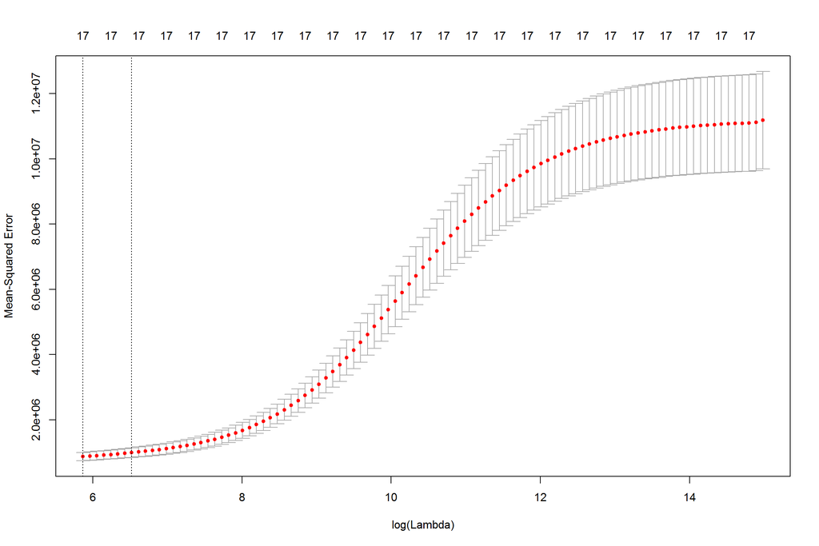

```
## The test error with Ridge Regression was was: 1219.97 with lambda = 353.6098
```

The test error with Ridge Regression was was:1219.97 with lambda = 353.609808

### 3.d

```
##     Private        Apps      Accept      Enroll   Top10perc   Top25perc
##           0           0           0           0           0           0
## F.Undergrad P.Undergrad    Outstate  Room.Board       Books    Personal
##           0           0           0           0           0           0
##         PhD    Terminal   S.F.Ratio perc.alumni      Expend   Grad.Rate
##           0           0           0           0           0           0
```

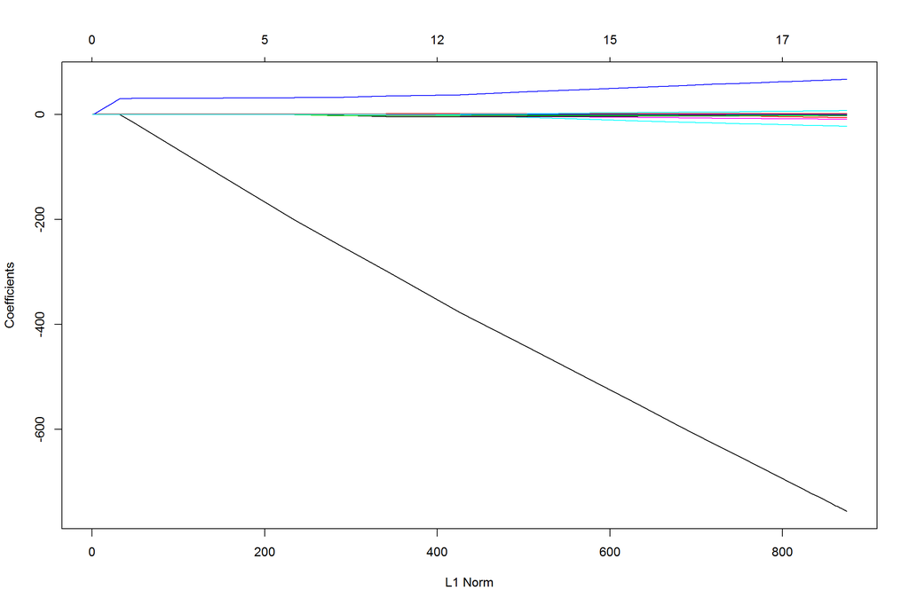

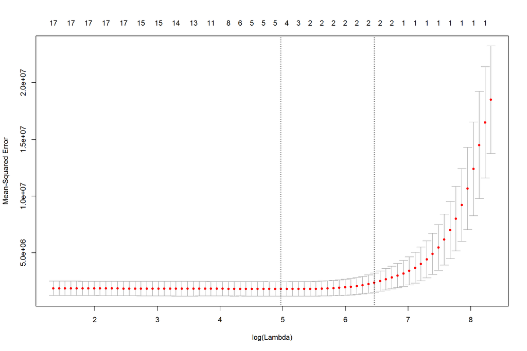

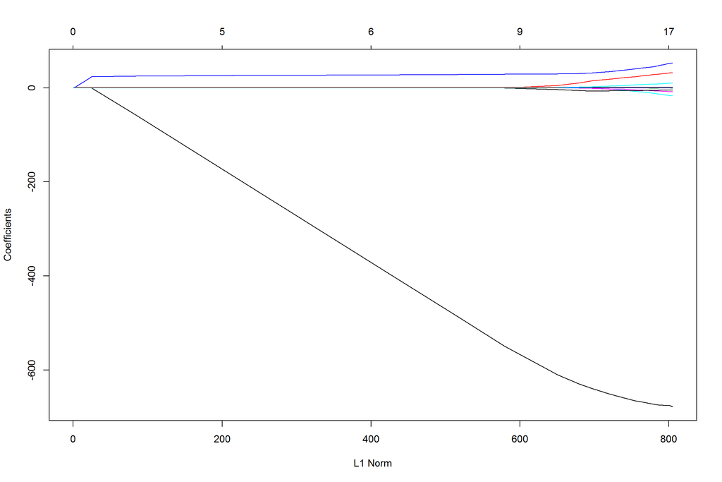

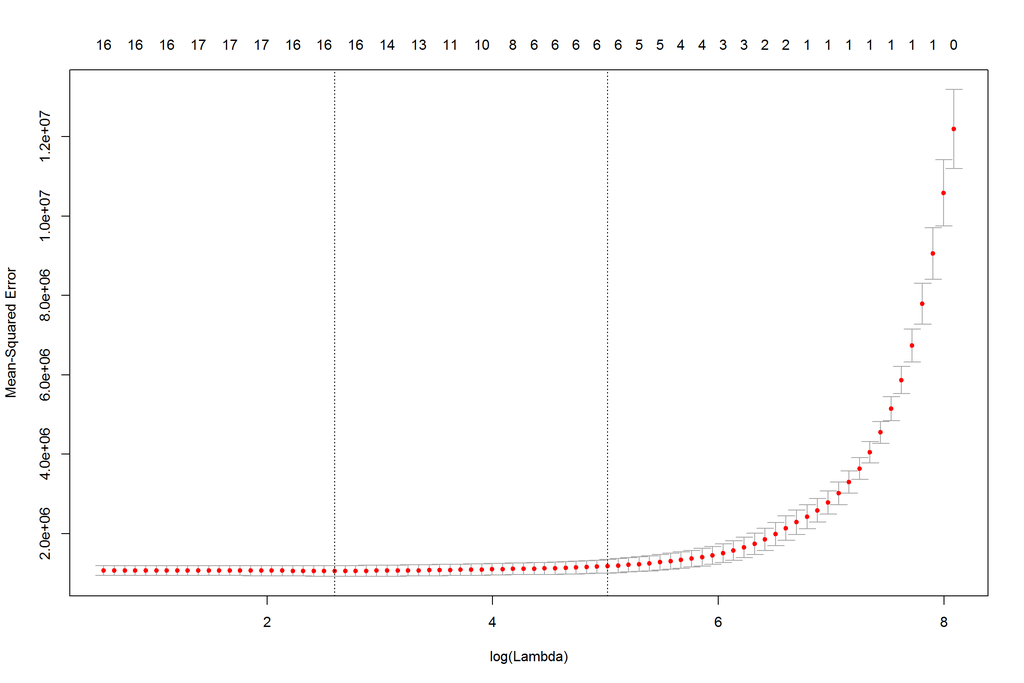

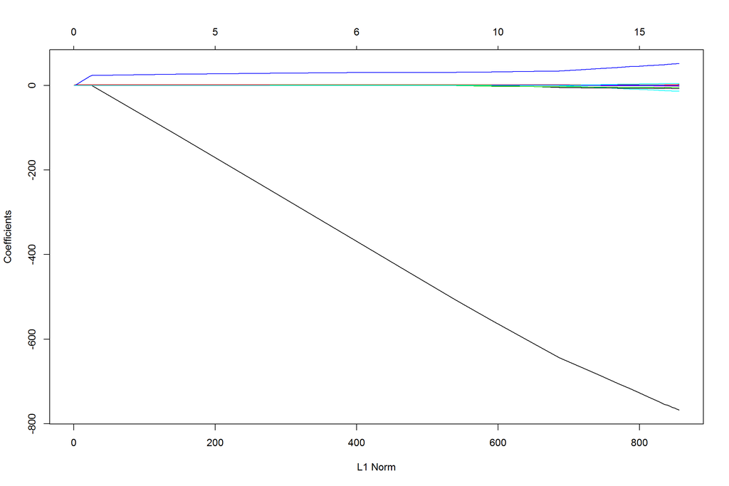

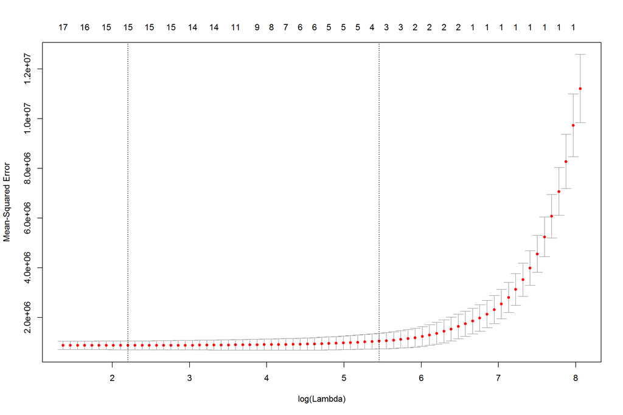

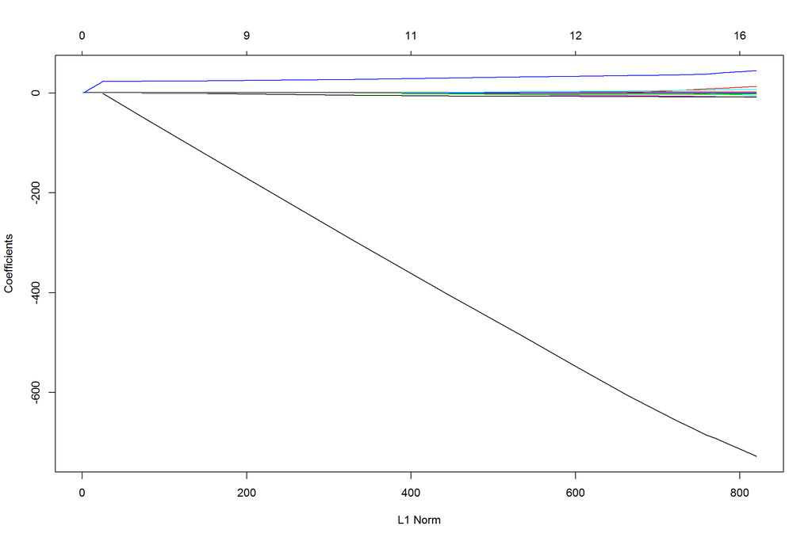

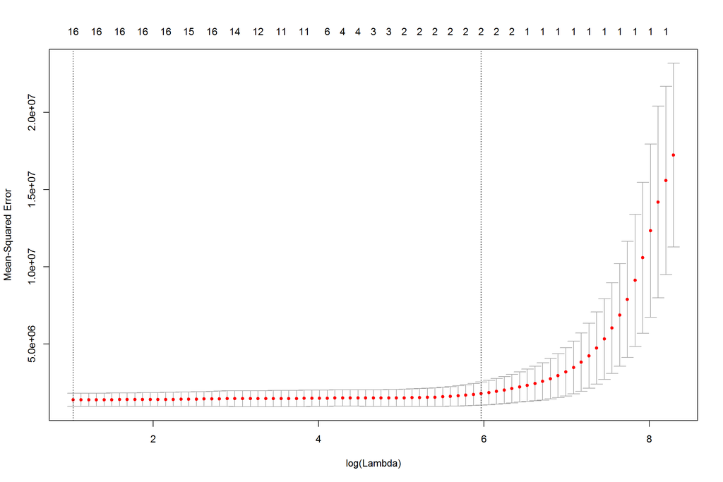

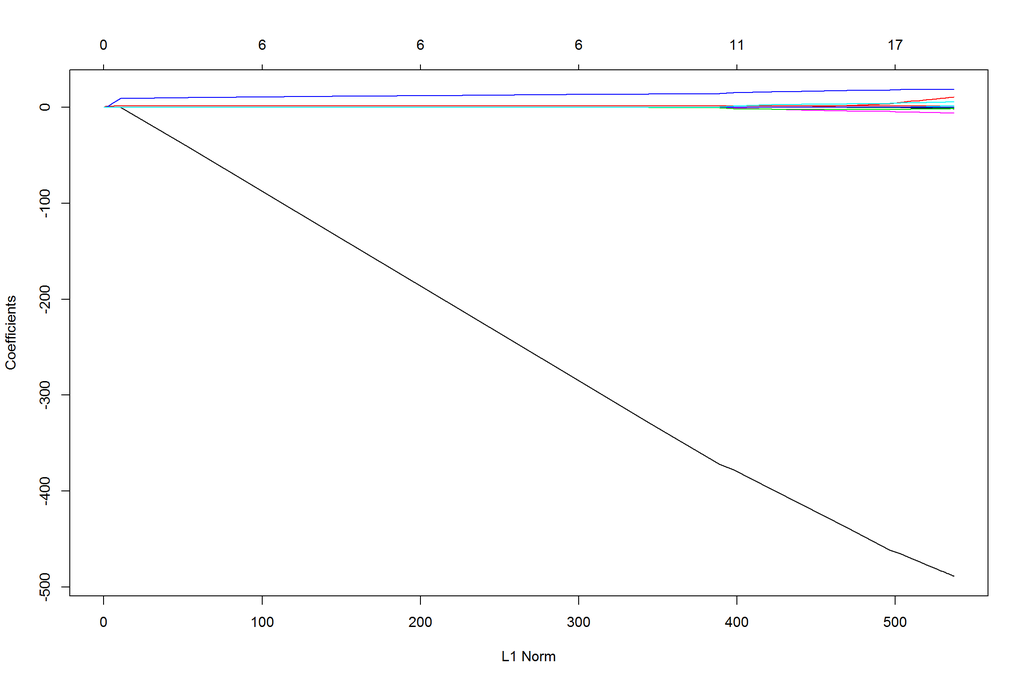

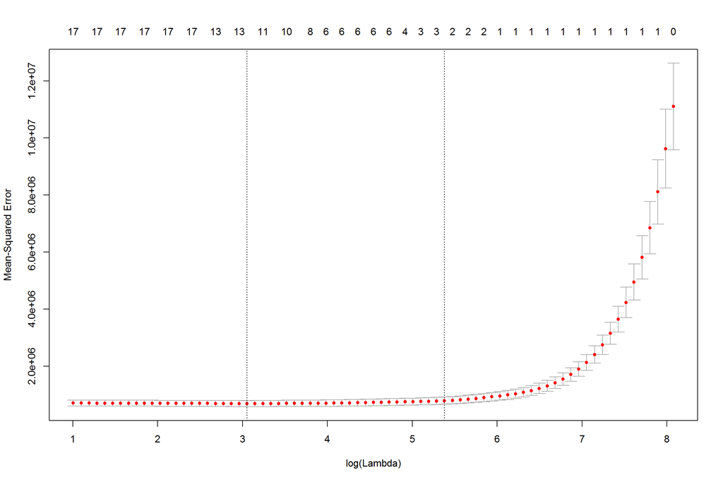

```
## The test error with Lasso Regression was was: 1240.95 with lambda = 21.19835
```

The test error with Lasso model was was:1240.95 with lambda = 21.1983511

### 3.e

```
##     Private        Apps      Accept      Enroll   Top10perc   Top25perc
##           0           0           0           0           0           0
## F.Undergrad P.Undergrad    Outstate  Room.Board       Books    Personal
##           0           0           0           0           0           0
##         PhD    Terminal   S.F.Ratio perc.alumni      Expend   Grad.Rate
##           0           0           0           0           0           0
```

```
## Data:    X dimension: 388 17
##  Y dimension: 388 1
## Fit method: svdpc
## Number of components considered: 17
##
## VALIDATION: RMSEP
## Cross-validated using 10 random segments.
##        (Intercept)  1 comps  2 comps  3 comps  4 comps  5 comps  6 comps
## CV            4335     4194     2363     2378     2106     1858     1858
## adjCV         4335     4194     2359     2379     1892     1845     1850
##        7 comps  8 comps  9 comps  10 comps  11 comps  12 comps  13 comps
## CV        1859     1867     1824      1822      1824      1829      1837
## adjCV     1852     1860     1815      1814      1815      1821      1828
##        14 comps  15 comps  16 comps  17 comps
## CV         1830      1819      1267      1285
## adjCV      1823      1790      1255      1272
##
## TRAINING: % variance explained
##       1 comps  2 comps  3 comps  4 comps  5 comps  6 comps  7 comps
## X      31.216    57.68    64.73    70.55    76.33    81.30    85.01
## Apps    6.976    71.47    71.58    83.32    83.44    83.45    83.46
##       8 comps  9 comps  10 comps  11 comps  12 comps  13 comps  14 comps
## X       88.40    91.16     93.36     95.38     96.94     97.96     98.76
## Apps    83.47    84.53     84.86     84.98     84.98     84.99     85.24
##       15 comps  16 comps  17 comps
## X        99.40     99.87    100.00
## Apps     90.87     93.93     93.97
```

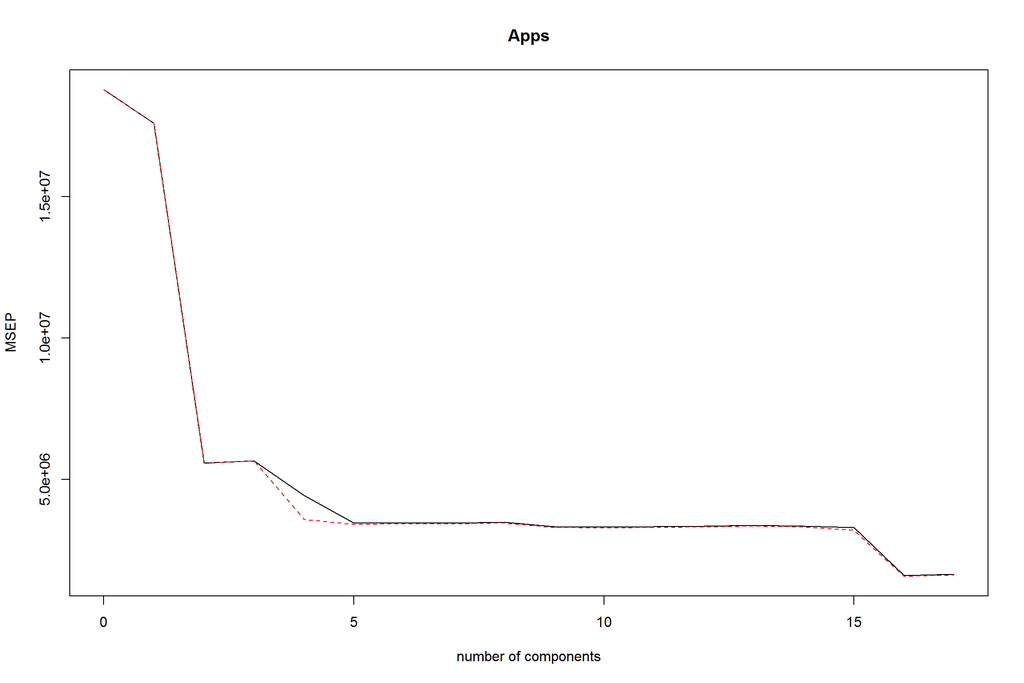

```
## Data:    X dimension: 388 17
##  Y dimension: 388 1
## Fit method: svdpc
## Number of components considered: 17
##
## VALIDATION: RMSEP
## Cross-validated using 10 random segments.
##        (Intercept)  1 comps  2 comps  3 comps  4 comps  5 comps  6 comps
## CV            3508     3549     1709     1734     1293     1297     1270
## adjCV         3508     3551     1706     1735     1269     1285     1266
##        7 comps  8 comps  9 comps  10 comps  11 comps  12 comps  13 comps
## CV        1235     1208     1219      1197      1197      1207      1205
## adjCV     1226     1198     1215      1193      1196      1203      1200
##        14 comps  15 comps  16 comps  17 comps
## CV         1201      1208      1091      1073
## adjCV      1196      1203      1085      1067
##
## TRAINING: % variance explained
##       1 comps  2 comps  3 comps  4 comps  5 comps  6 comps  7 comps
## X     32.0511    57.98    65.49    71.19    76.33    81.22    84.72
## Apps   0.1403    77.35    77.35    87.55    87.66    88.04    88.71
##       8 comps  9 comps  10 comps  11 comps  12 comps  13 comps  14 comps
## X       88.00    91.06     93.47     95.34      97.2     98.21     98.98
## Apps    89.15    89.19     89.67     89.69      89.8     89.88     89.95
##       15 comps  16 comps  17 comps
## X        99.52     99.87    100.00
## Apps     89.96     92.23     92.61
```

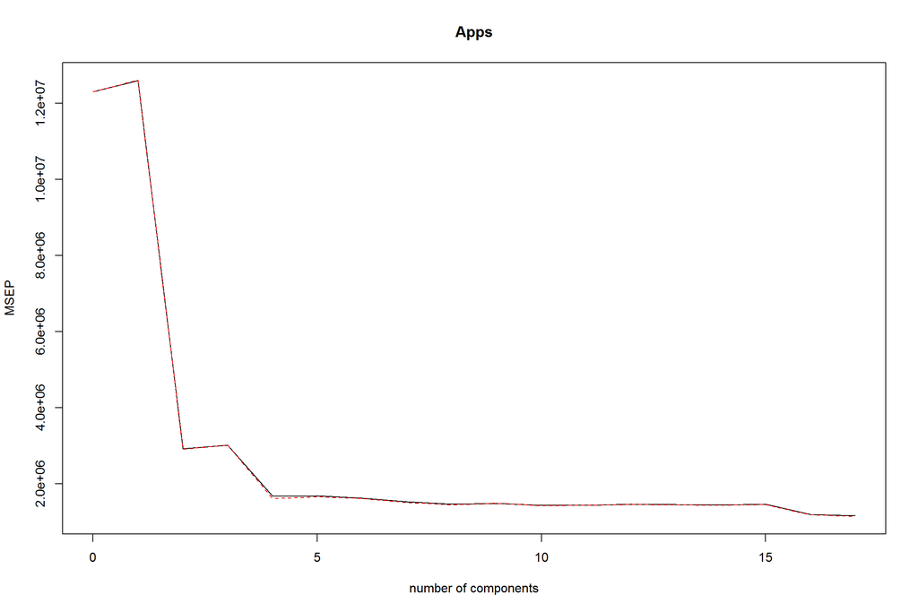

```
## Data:    X dimension: 388 17
##  Y dimension: 388 1
## Fit method: svdpc
## Number of components considered: 17
##
## VALIDATION: RMSEP
## Cross-validated using 10 random segments.
##        (Intercept)  1 comps  2 comps  3 comps  4 comps  5 comps  6 comps
## CV            3363     3332     1598     1550     1538     1209     1190
## adjCV         3363     3336     1596     1546     1541     1193     1185
##        7 comps  8 comps  9 comps  10 comps  11 comps  12 comps  13 comps
## CV        1195     1192     1186      1107      1100      1090      1090
## adjCV     1191     1190     1191      1103      1097      1088      1087
##        14 comps  15 comps  16 comps  17 comps
## CV         1090      1105     927.2     909.1
## adjCV      1087      1102     924.2     906.1
##
## TRAINING: % variance explained
##       1 comps  2 comps  3 comps  4 comps  5 comps  6 comps  7 comps
## X      30.684    57.24    64.18    70.18    75.61    80.50    84.59
## Apps    3.624    78.12    79.58    79.95    88.00    88.05    88.06
##       8 comps  9 comps  10 comps  11 comps  12 comps  13 comps  14 comps
## X       88.11    90.79     93.28     95.28     97.01     98.09     98.85
## Apps    88.12    88.20     89.97     90.16     90.40     90.51     90.56
##       15 comps  16 comps  17 comps
## X        99.44     99.83    100.00
## Apps     90.59     93.25     93.53
```